TLevitin · Cap. 6

Diseño y análisis de algoritmos

# Transformar. *Conquistar.*

A veces no conviene atacar el problema original. Cambia la instancia, la representación o incluso el problema; después resuelve una versión más amable.

**3**familias de transformación

**7**ideas algorítmicas clave

**O(n log n)**meta frecuente

**Patrón del capítulo**

Problema**→**Transformación

Nueva forma**→**Solución

El coste de transformar debe justificarse con una conquista más simple o reutilizable.

01 · Panorama

## Tres maneras de cambiar el juego

La técnica es una familia, no un único algoritmo. Cada variante cambia una cosa distinta.

Misma instancia*1*

### Simplificación

Convierte la entrada en una versión más conveniente. Preordenar, triangular un sistema o balancear un árbol son ejemplos.

**Pregunta guía:** ¿qué propiedad facilitaría el trabajo?

Mismos datos*2*

### Cambio de representación

Expresa la misma información de otra forma: arreglo ↔ heap, exponente ↔ bits, polinomio ↔ forma anidada.

**Pregunta guía:** ¿qué estructura hace barata la operación?

Otro problema*3*

### Reducción

Traduce el reto a un problema con solución conocida, resuélvelo y lleva la respuesta de vuelta al original.

**Pregunta guía:** ¿qué algoritmo existente puedo reutilizar?

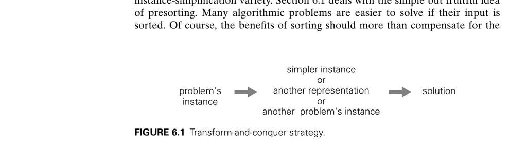

Figura 6.1 del capítulo: la instancia se transforma antes de obtener la solución.

02 · Simplificar

## Preordenar para ver patrones

Al ordenar, los duplicados quedan juntos y la moda se convierte en la racha más larga.

### Laboratorio de arreglo

Datos separados por comasObjetivo

**Idea:** ordena y luego recorre una sola vez.

### Entrada sin ordenar

**21**comparaciones potenciales · fuerza bruta

**≈ 20**operaciones · ordenar + recorrer

03 · Simplificar

## Gauss: de sistema a escalera

La eliminación hacia delante produce una matriz triangular; la sustitución hacia atrás termina la conquista.

### Sistema del ejemplo

2x₁ − x₂ + x₃ = 1  
4x₁ + x₂ − x₃ = 5  
x₁ + x₂ + x₃ = 0

**Paso 0:** matriz aumentada original.

A|b

#### Transformar

Eliminación hacia delante: O(n³).

#### Conquistar

Sustitución hacia atrás: O(n²).

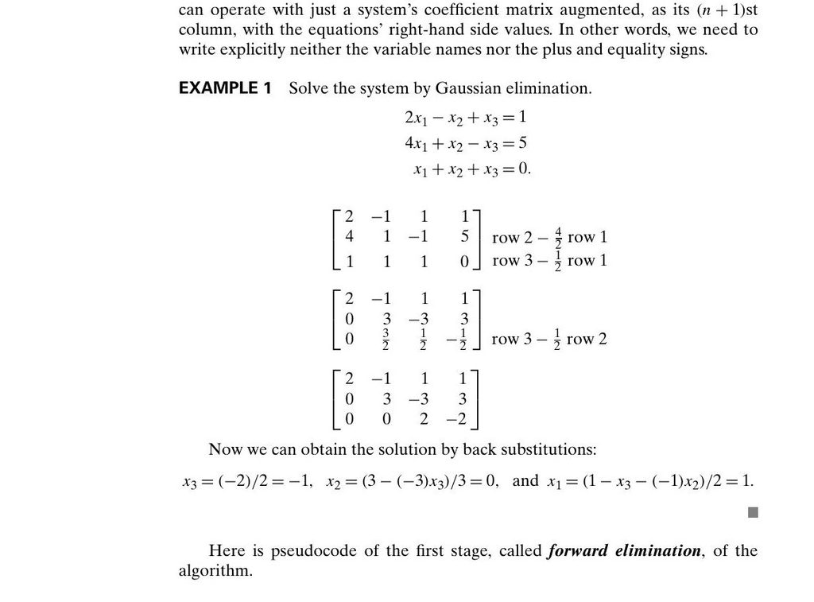

Ejemplo 6.2 del capítulo: operaciones por filas y sustitución hacia atrás.

04 · Balancear

## AVL: transformar mientras insertas

Un árbol binario de búsqueda mantiene alturas equilibradas mediante rotaciones. Buscar, insertar y eliminar permanecen en O(log n).

### Constructor AVL

Secuencia de inserción

**Listo:** inserta 5 para crear la raíz.

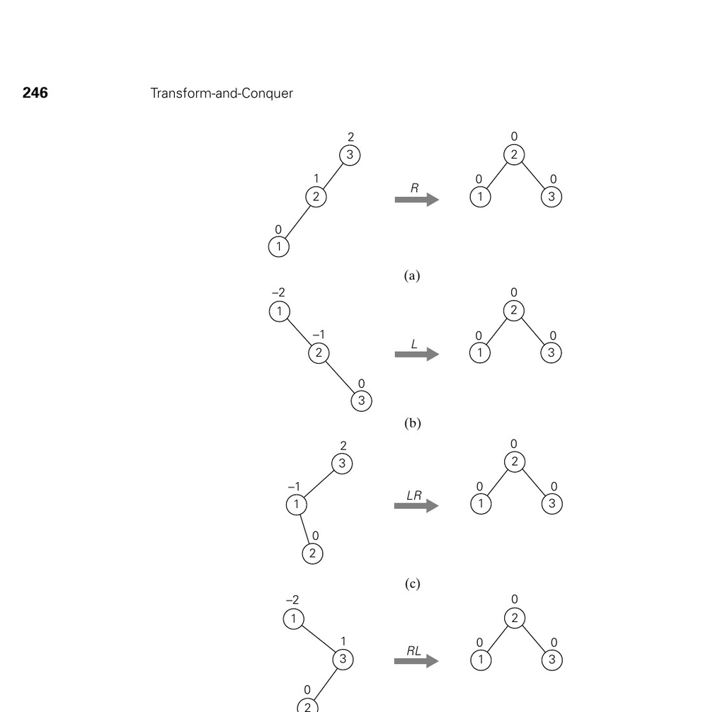

Figura 6.3: rotaciones R, L, LR y RL.

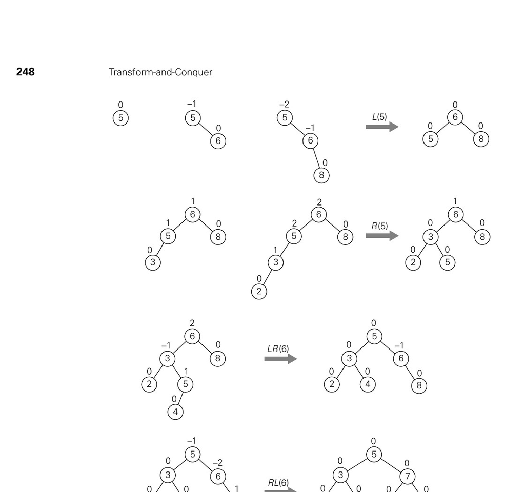

Figura 6.6: construcción con 5, 6, 8, 3, 2, 4, 7.

05 · Representar

## Heap: árbol y arreglo a la vez

La propiedad de dominancia convierte el máximo en acceso O(1). La construcción bottom-up es O(n); heapsort completa en O(n log n).

### Construcción bottom-up

Valores

**Inicio:** interpreta el arreglo como árbol completo.

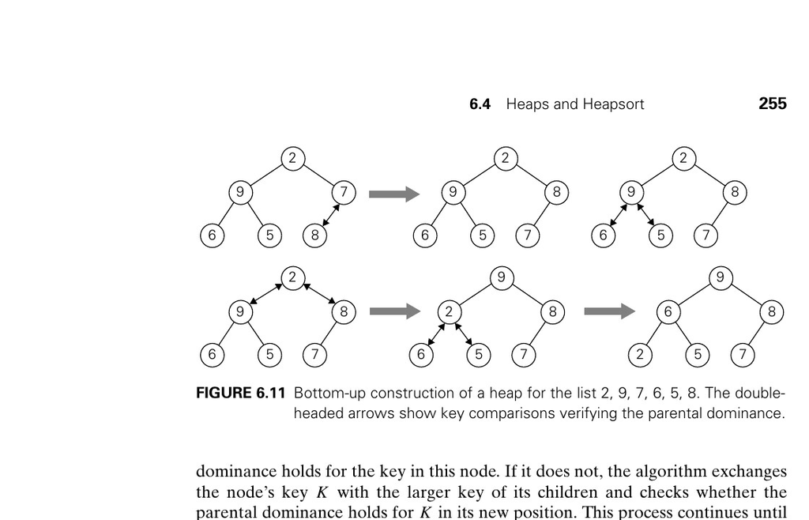

Figura 6.11: construcción bottom-up para 2, 9, 7, 6, 5, 8.

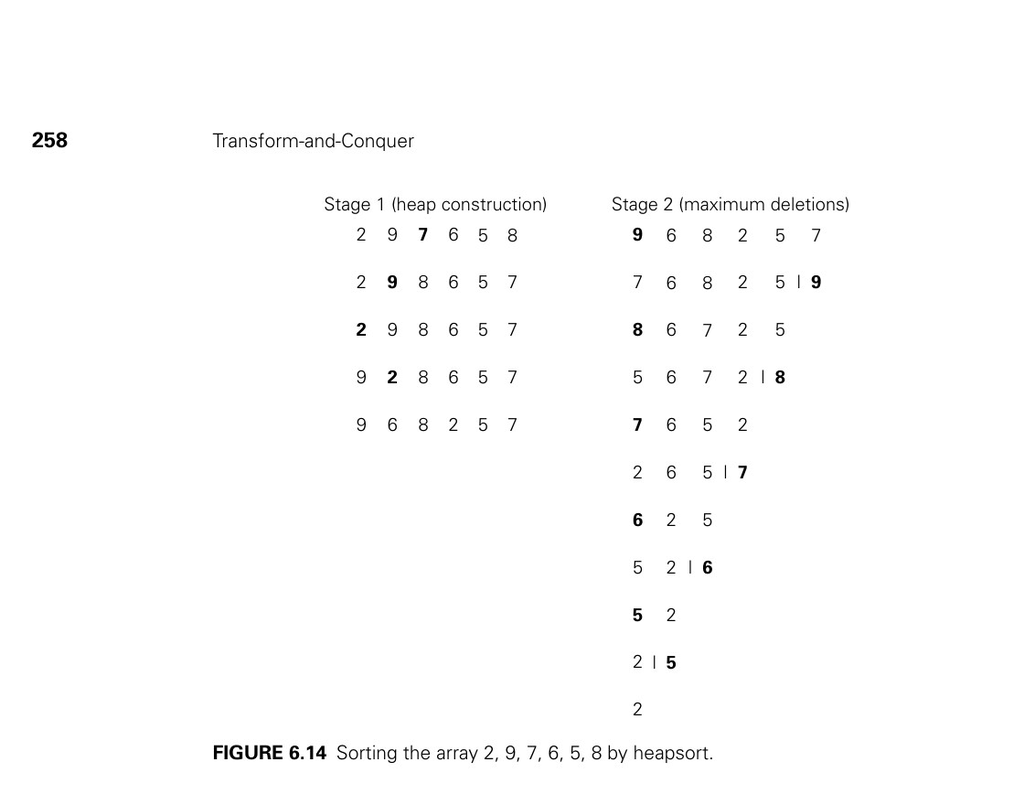

Figura 6.14: dos etapas de heapsort.

06 · Reescribir

## Horner y bits: menos trabajo

Dos cambios de representación elegantes: anidar un polinomio y leer el exponente en binario.

### Evaluador de Horner

Coeficientes, de mayor a menor gradoValor de x

**Resultado:** 160 con 4 multiplicaciones y 4 sumas.

2x⁴ − x³ + 3x² + x − 5

[output not shown]

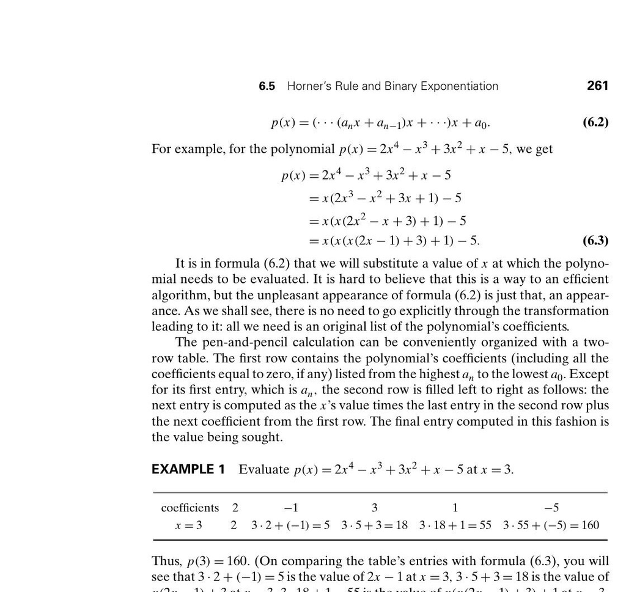

07 · Traducir

## Reducir sin perder la respuesta

La transformación debe ser correcta en ambos sentidos útiles y lo bastante barata para conservar la ventaja.

Aritmética

### mcm → mcd

mcm(m,n) = |m·n| / mcd(m,n). Reutiliza el algoritmo de Euclides.

Grafos

### Puzzle → espacio de estados

Cada situación legal es un vértice; cada movimiento permitido, una arista. Resolver equivale a hallar un camino.

Modelado

### Decisión → optimización

Variables, restricciones y función objetivo convierten una historia en un programa lineal.

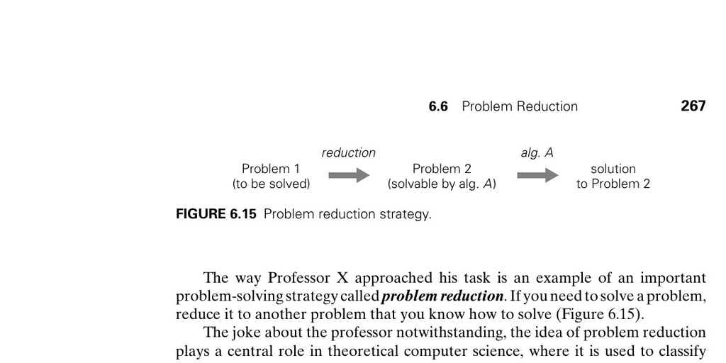

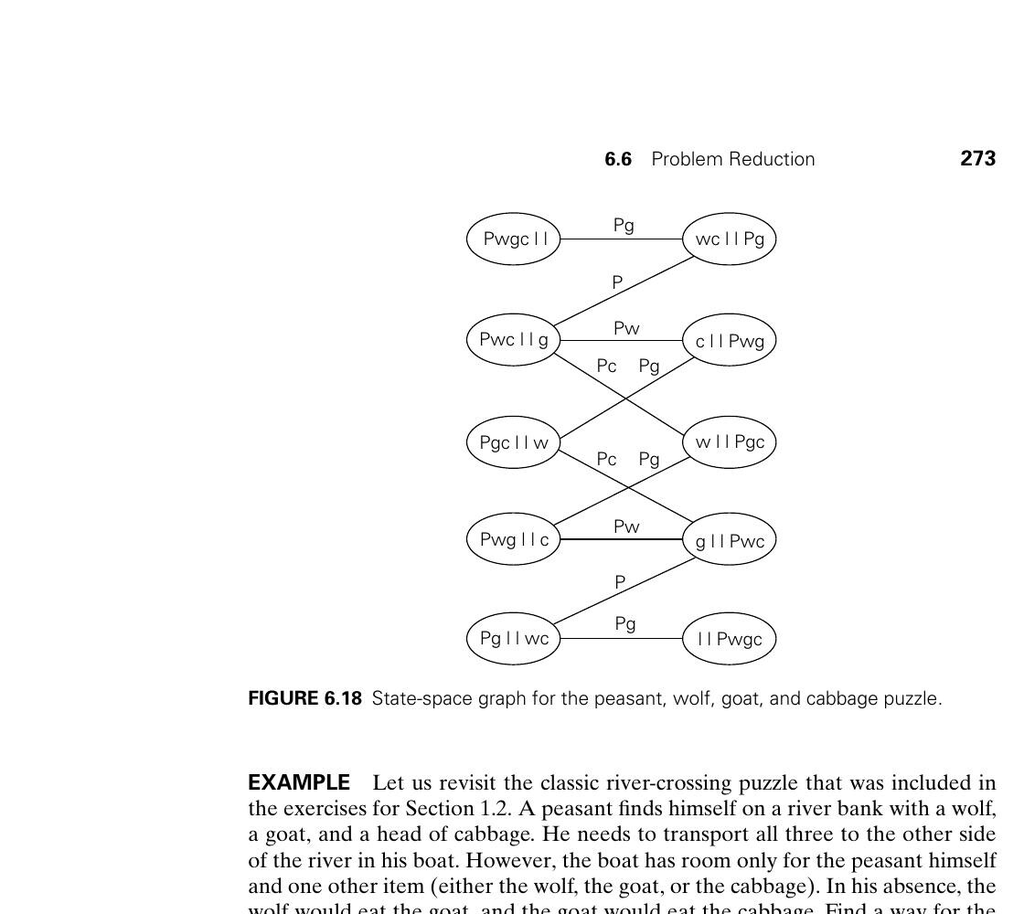

Figura 6.18: grafo de estados del campesino, lobo, cabra y col.

**Chequeo de calidad de una reducción:** (1) preserva la solución, (2) la transformación es eficiente, (3) el algoritmo reutilizado mejora una alternativa directa y (4) la respuesta puede traducirse de vuelta.

08 · Autoevaluación

## Reto de transformación

Ocho preguntas. La retroalimentación es inmediata y puedes repetir con el orden barajado.

Pregunta 1 de 8

Contenido desarrollado a partir de Anany Levitin, *Introduction to the Design & Analysis of Algorithms*, capítulo 6, “Transform-and-Conquer”. Las imágenes reproducen figuras del PDF proporcionado por el usuario con finalidad educativa.